# Factors Associated with Hospitalization for Abdominal Pain

# Abstract

## Background

Acute abdominal pain is a common presentation in clinical settings, and identifying characteristics associated with hospital admission may help clinicians assess patients and determine appropriate management.

## Objective

This study investigated the association between demographic, clinical, physical examination, and laboratory characteristics and hospital admission among patients presenting with abdominal pain.

## Methods

A dataset containing 957 patients presenting with abdominal pain was analysed. Univariable analyses were performed using chi-square tests, Fisher’s exact tests, and logistic regression to identify variables associated with hospital admission. Variables demonstrating statistical significance in the univariable analysis were included in a multivariable logistic regression model to assess whether their associations remained significant after adjustment for other variables. Model discrimination was assessed using the area under the receiver operating characteristic curve (AUC).

## Results

Six variables remained statistically significantly associated with hospital admission in the multivariable logistic regression: vomiting, epigastric tenderness, lumbar tenderness, WBC, obstructive LFT findings, and lipase. RIF tenderness showed borderline evidence of an association with hospital admission (p = 0.050). The multivariable model demonstrated good discrimination between patients who were and were not admitted to hospital, with an AUC of 0.879.

## Conclusion

Vomiting, epigastric tenderness, lumbar tenderness, WBC, obstructive LFT findings, and lipase were independently associated with hospital admission after adjustment for other variables included in the model. The overall multivariable model demonstrated good discrimination, suggesting that a combination of patient characteristics may be useful for distinguishing patients who are admitted from those who are not. However, the observational nature of the study prevents causal conclusions, and further research using larger datasets and external validation is required.

# Introduction

Abdominal pain is discomfort anywhere in your abdomen, the region between your ribs and pelvis (Cleveland Clinic, 2025). Many patients who present to the emergency department (ER) do so because of abdominal pain, which accounts for 7% of ED visits in the United States and represents more than 3 million patient encounters. Evaluating abdominal pain is not straightforward since it requires consideration of many possible underlying conditions, including pathology outside the abdomen itself. It is important for clinicians to evaluate the cause of a patient’s abdominal pain since the pain can potentially represent a life-threatening pathology. Abdominal pain evaluation requires consideration of a broad range of possible diagnoses ranging from a patient’s clinical records, diagnostic imaging, physical examinations, and laboratory testing. (Wolfe et al., 2022).

Previous research has investigated factors associated with emergency department length of stay among patients presenting with abdominal pain and found that the patient characteristics associated with longer ER stays were age, rounds of blood test, interdepartmental consultation, and the need for ultrasonography (Dadeh & Phunyanantakorn, 2020). The study focused on emergency department length of stay rather than hospital admission, but it demonstrates that patient and clinical characteristics can influence emergency department management, supporting further investigation of factors associated with hospital admission.

The aim of this study is to investigate the demographic, clinical, laboratory, and imaging factors associated with hospital admission among patients presenting with abdominal pain. Specifically, the study addresses the following research question: “Which demographic, clinical, laboratory, and imaging factors are associated with hospital admission among patients presenting with abdominal pain?”

# Methods

## Ethics and Data Access Requirements

The dataset was obtained from Kings College Hospital Dubai for educational research purposes via researchers at the institution and was used for secondary analysis in this study. The data was originally collected for research investigating factors associated with hospital admission among patients presenting with abdominal pain.

To obtain dataset access, an ethics form from Kings College Hospital Dubai was completed which asked questions about the study aims, how personal identifiable information (PII) was protected, and methods used in the study. The required King’s College Hospital Dubai ethics documentation was completed, and approval from the relevant ethics committees was obtained before access to the dataset was granted. No additional ethical approval was required for this secondary analysis.

Details about the ethical approval for the original study were not provided to the researcher. The Kings College Hospital Dubai ethics form identified the Dubai Scientific Research Ethics Committee (DSREC) and the Dubai Health Authority (DHA) as relevant bodies in relation to the study.

Patient privacy was protected because the dataset provided to the researcher did not contain any personally identifiable information (PII). The dataset was also provided for restricted research use and was not publicly distributed.

## Dataset Elements and Coverage

### Dataset Elements and Coverage Section Table of Contents

1. Loading and viewing the original dataset
2. Rows and Columns in Dataset
3. Dependent Variable
4. Independent Variables
5. Variables not selected

### Loading and viewing the original dataset

- Click here to go back to the “Analytical Methods used on the Data” Table of Contents

The dataset was downloaded and accessed through a local working directory. The dataset was not publicly distributed because it contains confidential patient information and was provided for restricted research use.

The dataset was imported into R using the `read_excel()` function.

```r
#loading the dataset via a local working directory
df <- read_excel('C:/Users/hussainsarfraz/Desktop/micro masters HDS/HDS_08_HUSSAINSARFRAZ_2608/KCH_abdominal_pain_dataset.xlsx')
#viewing the first 10 rows of the dataset
kable(head(df))
```

| Age (years) | Gender (Male/Female) | Comorbid: Diabetes | Comorbid: Hypertension | Comorbid: CKD | Comorbid: IHD | Comorbid: Bronchial Asthma | Comorbid: Dyslipidemia | Comorbid: Others | Ethnicity: Arabs | Ethnicity: Muslims (non-Arabs) | Ethnicity: Others | Nationality: Bahraini | Nationality: Other Arabs | Nationality: Expats | Abdominal pain: Localized | Abdominal pain: Epigastric/Upper quadrant | Abdominal pain: RIF/LIF | Abdominal pain: Lumbar | Abdominal pain: Suprapubic | Abdominal pain: Generalized | Duration of pain: Acute <24h | Duration of pain: >24h | Fever (Y/N) | Vomiting (Y/N) | Diarrhea (Y/N) | Constipation (Y/N) | Radiation of pain (Y/N) | Pain score (1-10) | Dysuria (Y/N) | … |
| --- | --- | --- | --- | --- | --- | --- | --- | --- | --- | --- | --- | --- | --- | --- | --- | --- | --- | --- | --- | --- | --- | --- | --- | --- | --- | --- | --- | --- | --- | --- |
| 50 | M | Y | Y | N | N | N | Y | N | Y | N | N | Y | N | N | Y | Y | N | N | N | N | Y | N | N | N | N | N | N | 7 | N | … |
| 14 | F | N | N | N | N | N | N | N | Y | N | N | Y | N | N | Y | N | Y, RIF | N | N | N | Y | N | N | N | N | N | N | 4 | N | … |
| 57 | F | N | N | N | N | N | N | N | Y | N | N | N | Y | N | N | N | N | N | N | Y | Y | N | N | N | N | N | N | 7 | N | … |
| 22 | M | N | N | N | N | N | N | N | Y | N | N | Y | N | N | Y | Y | N | N | N | N | Y | N | N | N | Y | N | N | 3 | N | … |
| 18 | M | N | N | N | N | N | N | N | Y | N | N | Y | N | N | Y | Y | Y, RIF | N | N | N | Y | N | N | N | N | N | N | 6 | N | … |
| 72 | M | Y | Y | N | N | N | Y | N | Y | Y | N | Y | N | N | N | N | N | N | N | Y | Y | N | N | Y | N | Y | N | 2 | N | … |

### Rows and Columns in Dataset

- Click here to go back to the “Analytical Methods used on the Data” Table of Contents

There are 957 observations which represent patients who presented with abdominal pain at King’s College Hospital Dubai and 82 variables in the dataset. For the purpose of this study, the 82 variables have been categorised into 9 groups. Hospital admission was treated as the primary outcome variable. The groups are:

1. Patient demographics
2. Comorbidities
3. Pain characteristics
4. Pain location
5. Associated symptoms
6. Vital signs
7. Physical examination findings
8. Hernia findings
9. Laboratory variables

The participants’ age ranged from 14-96 years. Of the 957 patients, 587 (61.3%) were female, 369 (38.6%) were male, and one record (0.1%) contained a `D` value for gender.

The inclusion criteria for the original study were not provided to the researcher. The secondary analysis included all patients contained within the anonymised dataset provided by King’s College Hospital Dubai.

For the secondary analysis, variables with substantial missing data that were considered unsuitable for analysis were excluded. No additional patient-level inclusion or exclusion criteria were applied.

The time period during which the original patient data were collected was not provided with the dataset.

```r
#displaying the number of rows and columns in the dataset
print(paste0('Numbers of rows: ', nrow(df)))
```

```
## [1] "Numbers of rows: 957"
```

```r
print(paste0('Numbers of columns: ', ncol(df)))
```

```
## [1] "Numbers of columns: 82"
```

```r
#showing the summary statistics of the age column
summary(df$`Age (years)`)
```

```
##    Min. 1st Qu.  Median    Mean 3rd Qu.    Max.
##   14.00   27.00   38.00   42.66   58.00   96.00
```

```r
#showing the distribution of gender
table(df$`Gender (Male/Female)`)
```

```
##
##   D   F   M
##   1 587 369
```

```r
prop.table(table(df$`Gender (Male/Female)`))
```

```
##
##           D           F           M
## 0.001044932 0.613375131 0.385579937
```

### Dependent Variable

- Click here to go back to the “Analytical Methods used on the Data” Table of Contents

Since the research question focuses on investigating factors associated with hospital admission, three potential dependent variables were identified: `Admitted (Y/N)`, `ward admission (Level of Admission: Ward)`, and `ICU admission (Level of Admission: ICU)`. The frequency table distributions for all three variables were examined to determine which one to select.

The frequency table showed that 952 of 956 non-missing observations (99.58%) were not admitted to the ICU, while only four patients were admitted to the ICU. One observation was missing. The small number of ICU admissions (n = 4) would result in an extremely imbalanced outcome and would provide insufficient observations in the admission group for a reliable analysis. Therefore, `ICU admission (Level of Admission: ICU)` was excluded as a potential dependent variable.

```r
table(df$`Level of Admission: ICU`)
```

```
##
##   M   N   Y
##   1 952   4
```

```r
table(df$`Admitted (Y/N)`)
```

```
##
##   N N/A   Y
## 776   1 180
```

```r
table(df$`Level of Admission: Ward`)
```

```
##
##   N   Y
## 783 174
```

Although `ward admission (Level of Admission: Ward)` had a sufficient number of admission cases, it represents a subset of admitted patients. Therefore, `Admitted (Y/N)` was selected as the dependent variable since it aligns with the research question of predicting hospital admission.

### Independent Variables

- Click here to go back to the “Analytical Methods used on the Data” Table of Contents

**Demographic Variables**

The demographic variables describe the patient’s age, gender, ethnicity, and nationality. There are a total of 8 variables under this section.

1. `Age (years)`
2. `Gender (Male/Female)`
3. `Ethnicity: Arabs`
4. `Ethnicity: Muslims (non-Arabs)`
5. `Ethnicity: Others`
6. `Nationality: Bahraini`
7. `Nationality: Other Arabs`
8. `Nationality: Expats`

**Comorbidities**

The comorbidities variables describe whether the patient had any other underlying health conditions. There are a total of 6 variables under this section.

1. `Comorbid: Diabetes`
2. `Comorbid: Hypertension`
3. `Comorbid: CKD`
4. `Comorbid: IHD`
5. `Comorbid: Bronchial Asthma`
6. `Comorbid: Dyslipidemia`

**Pain Characteristics**

The pain characteristic variables describe the nature of the abdominal pain instead of the specific location where the pain occurs. There are a total of 6 variables under this section.

1. `Duration of pain: Acute <24h`
2. `Duration of pain: >24h`
3. `Radiation of pain (Y/N)`
4. `Pain score (1-10)`
5. `Nature of pain: Continuous`
6. `Nature of pain: Intermittent`

**Pain Location**

The pain location variables describe the anatomical location of the patient’s abdominal pain. There are a total of 6 variables under this section.

1. `Abdominal pain: Localized`
2. `Abdominal pain: Epigastric/Upper quadrant`
3. `Abdominal pain: RIF/LIF`
4. `Abdominal pain: Lumbar`
5. `Abdominal pain: Suprapubic`
6. `Abdominal pain: Generalized`

**Associated Symptoms**

The associated symptoms variables describe additional symptoms reported by the patient during abdominal pain. There are a total of 5 variables under this section.

1. `Fever (Y/N)`
2. `Vomiting (Y/N)`
3. `Diarrhea (Y/N)`
4. `Constipation (Y/N)`
5. `Dysuria (Y/N)`

**Vital Signs**

The vital signs variables describe measurements recorded from a patient during assessment. There are a total of 6 variables under this section.

1. `Temp`
2. `Tachycardic (Y/N)`
3. `HEART Rate`
4. `Hypotensive (Y/N)`
5. `Blood Pressure`
6. `RBS`

**Physical Examination Findings**

The physical examination findings variables describe clinical signs identified during the patient’s physical examination. There are a total of 11 variables under this section.

1. `Tenderness: Epigastric`
2. `Tenderness: RHC`
3. `Tenderness: LHC`
4. `Tenderness: Lumbar`
5. `Tenderness: Umbilical`
6. `Tenderness: RIF`
7. `Tenderness: LIF`
8. `Tenderness: Suprapubic`
9. `Rebound tenderness (Y/N)`
10. `Murphy (Y/N)`
11. `Renal Punch (Y/N)`

**Hernia Findings**

The hernia findings variables describe the presence and clinical classification of hernias identified during assessment. There are a total of 3 variables under this section.

1. `Hernia: Obstructive`
2. `Hernia: Reducible`
3. `Hernia: No`

**Laboratory Variables**

The laboratory variables describe findings derived from a patient’s blood/urine laboratory tests. There are a total of 5 variables under this section.

1. `WBC`
2. `LFTs: Obstructive`
3. `LFTs: Non-obstructive`
4. `Lipase`
5. `UTI (Y/N)`

### Variables not selected

- Click here to go back to the “Analytical Methods used on the Data” Table of Contents

The following variables were excluded from the analysis because they weren’t relevant to the research outcome, had no variation, contained entries that couldn’t be meaningfully analysed, or had substantial missing data Descriptions of these variables and the reasons for their exclusion are provided in the metadata section.

**Variables that were outcome-related**

1. `Discharge (Y/N)`
2. `Reffered (Y/N)`
3. `Level of Admission: Ward`
4. `Level of Admission: ICU`
5. `Service of Admission: IM`
6. `Service of Admission: GS`
7. `Service of Admission: Urology`

**Variables with no variation**

`Hernia: Gangrenous`

**Free-text / unstructured variables**

1. `Comorbid: Others`
2. `Scar marks for abdominal surgery (Y/N)`
3. `CT: Organ perforation`
4. `...80`
5. `...81`
6. `...82`

**Variables with a huge amount of NA values**

Imaging

1. `Ultrasound: Appendicitis`
2. `Ultrasound: Cholecystitis`
3. `Ultrasound: Dilated CBD`
4. `Ultrasound: Cholelithiasis`
5. `Ultrasound: Hemorrhagic ovarian cyst`
6. `CT: Intestinal Obstruction`
7. `CT: Diverticular disease`
8. `AXR: Intestinal obstruction`
9. `AXR: Fecal loading`

Laboratory

1. `Neutrophils`
2. `CRP`

## Metadata

### Metadata Section Table of Contents

**Note:** To access all column descriptions please refer to Appendix A

1. Dependent Variable Description
2. Independent Variables Descriptions
3. Variables not selected Descriptions

### Dependent Variable Description

- Click here to go back to the “Analytical Methods used on the Data” Table of Contents

| Variable | Description | Type |
| --- | --- | --- |
| `Admitted (Y/N)` (Y/N) | Whether the patient has been admitted to the hospital | Categorical Nominal |

### Independent Variables Descriptions

- Click here to go back to the “Analytical Methods used on the Data” Table of Contents

**Demographic Variables**

The demographic variables describe the patient’s age, gender, ethnicity, and nationality. There are a total of 8 variables under this section.

| Variable | Description | Type |
| --- | --- | --- |
| `Age (years)` (14-96) | Patient’s Age | Numerical Discrete |
| `Gender (Male/Female)` (primarily coded as M/F; rare anomalous entries observed) | Patient’s Gender | Categorical Nominal |
| `Ethnicity: Arabs` (primarily coded as Y/N; rare anomalous entries observed) | Whether the patient is Arab | Categorical Nominal |
| `Ethnicity: Muslims (non-Arabs)` (Y/N) | Whether the patient is a non-Arab Muslim | Categorical Nominal |
| `Ethnicity: Others` (Y/N) | Whether the patient belongs to an ethnicity category other than Arab or Muslim (non-Arab) | Categorical Nominal |
| `Nationality: Bahraini` (Y/N) | Whether the patient is a Bahraini national | Categorical Nominal |
| `Nationality: Other Arabs` (Y/N) | Whether the patient is a national of another Arab country | Categorical Nominal |
| `Nationality: Expats` (primarily coded as Y/N; rare anomalous entries observed) | Whether the patient is a Expat (non-Arab foreign national residing in the UAE) | Categorical Nominal |

**Comorbidities**

| Variable | Description | Type |
| --- | --- | --- |
| `Comorbid: Diabetes` (Y/N) | Whether the patient has diabetes as a comorbidity | Categorical Nominal |
| `Comorbid: Hypertension` (Y/N) | Whether the patient has hypertension as a comorbidity | Categorical Nominal |
| `Comorbid: CKD` (primarily coded as Y/N; rare anomalous entries observed) | Whether the patient has Chronic Kidney Disease (CKD) as a comorbidity | Categorical Nominal |
| `Comorbid: IHD` (Y/N) | Whether the patient has Ischemic Heart Disease (IHD) as a comorbidity | Categorical Nominal |
| `Comorbid: Bronchial Asthma` (primarily coded as Y/N; rare anomalous entries observed) | Whether the patient has Bronchial Asthma as a comorbidity | Categorical Nominal |
| `Comorbid: Dyslipidemia` (primarily coded as Y/N; rare anomalous entries observed) | Whether the patient has Dyslipidemia as a comorbidity | Categorical Nominal |

**Pain Characteristics**

The pain characteristic variables describe the nature of the abdominal pain instead of the specific location where the pain occurs. There are a total of 6 variables under this section.

| Variable | Description | Type |
| --- | --- | --- |
| `Duration of pain: Acute <24h` (primarily coded as Y/N; rare anomalous entries observed) | Whether the patients abdominal pain was present for less than 24 hours | Categorical Nominal |
| `Duration of pain: >24h` (Y/N) | Whether the patients abdominal pain was present for more than 24 hours | Categorical Nominal |
| `Radiation of pain (Y/N)` (Y/N) | Whether the patient’s abdominal pain radiated or spread from its primary location to another area of the body. | Categorical Nominal |
| `Pain score (1-10)` (1-10) | The severity of abdominal pain that a patient felt from a scale of 1-10 | Numerical Discrete |
| `Nature of pain: Continuous` (primarily coded as Y/N; rare anomalous entries observed) | Whether the patient experienced continuous abdominal pain | Categorical Nominal |
| `Nature of pain: Intermittent` (Y/N) | Whether the patient experienced intermittent abdominal pain | Categorical Nominal |

**Pain Location**

The pain location variables describe the anatomical location of the patient’s abdominal pain. There are a total of 6 variables under this section.

| Variable | Description | Type |
| --- | --- | --- |
| `Abdominal pain: Localized` (Y/N) | Whether the patient had localized abdominal pain | Categorical Nominal |
| `Abdominal pain: Epigastric/Upper quadrant` (Y/N) | Whether the patient had epigastric/upper quadrant abdominal pain | Categorical Nominal |
| `Abdominal pain: RIF/LIF` (Values were primarily recorded as Y/N but contained additional location-specific entries (e.g., “Y, RIF”, “LIF”)) | Whether the patient experienced pain in the right iliac fossa (RIF) or left iliac fossa (LIF) | Categorical Nominal |
| `Abdominal pain: Lumbar` (Y/N) | Whether the patient experienced lumbar abdominal pain | Categorical Nominal |
| `Abdominal pain: Suprapubic` (primarily coded as Y/N; rare anomalous entries observed) | Whether the patient experienced suprapubic abdominal pain | Categorical Nominal |
| `Abdominal pain: Generalized` (primarily coded as Y/N; rare anomalous entries observed) | Whether the patient had generalized abdominal pain | Categorical Nominal |

**Associated Symptoms**

The associated symptoms variables describe additional symptoms reported by the patient during abdominal pain. There are a total of 5 variables under this section.

| Variable | Description | Type |
| --- | --- | --- |
| `Fever (Y/N)` (Y/N) | Whether the patient had a fever | Categorical Nominal |
| `Vomiting (Y/N)` (Y/N) | Whether the patient vomited | Categorical Nominal |
| `Diarrhea (Y/N)` (primarily coded as Y/N; rare anomalous entries observed) | Whether the patient had diarrhea | Categorical Nominal |
| `Constipation (Y/N)` (primarily coded as Y/N; rare anomalous entries observed) | Whether the patient had constipation | Categorical Nominal |
| `Dysuria (Y/N)` (Y/N) | Whether the patient had pain, discomfort, or a burning sensation during urination | Categorical Nominal |

**Vital Signs**

The vital signs variables describe measurements recorded from a patient during assessment. There are a total of 6 variables under this section.

| Variable | Description | Type |
| --- | --- | --- |
| `Temp` (36.0 - 39.8) | Patient’s temperature | Numerical Continuous |
| `Tachycardic (Y/N)` (Y/N) | Whether the patient was tachycardic (had an abnormally elevated heart rate) | Categorical Nominal |
| `HEART Rate` (50-150) | Patient’s heart rate | Numerical discrete |
| `Hypotensive (Y/N)` (primarily coded as Y/N; rare anomalous entries observed) | Whether the patient was hypotensive (had abnormally low blood pressure) | Categorical Nominal |
| `Blood Pressure` (14-221) | Patient’s blood pressure | Numerical Discrete |
| `RBS` (primarily numeric; rare anomalous entries observed) | Patient’s random blood sugar levels (RBS) | Numerical Continuous |

**Physical Examination Findings**

| Variable | Description | Type |
| --- | --- | --- |
| `Tenderness: Epigastric` (Y/N) | Whether epigastric tenderness was identified during physical examination | Categorical Nominal |
| `Tenderness: RHC` (Y/N) | Whether Right Hypochondriac (RHC) tenderness was identified during physical examination | Categorical Nominal |
| `Tenderness: LHC` (primarily coded as Y/N; rare anomalous entries observed) | Whether Left Hypochondriac (LHC) tenderness was identified during physical examination | Categorical Nominal |
| `Tenderness: Lumbar` (Y/N) | Whether lumbar tenderness was identified during physical examination | Categorical Nominal |
| `Tenderness: Umbilical` (Y/N) | Whether umbilical tenderness was identified during physical examination | Categorical Nominal |
| `Tenderness: RIF` (Y/N) | Whether right iliac fossa (RIF) tenderness was identified during physical examination | Categorical Nominal |
| `Tenderness: LIF` (primarily coded as Y/N; rare anomalous entries observed) | Whether left iliac fossa (LIF) tenderness was identified during physical examination | Categorical Nominal |
| `Tenderness: Suprapubic` (primarily coded as Y/N; rare anomalous entries observed) | Whether suprapubic tenderness was identified during physical examination | Categorical Nominal |
| `Rebound tenderness (Y/N)` (Y/N) | Whether rebound tenderness was identified during physical examination | Categorical Nominal |
| `Murphy (Y/N)` (Y/N) | Whether a patient has a murphy sign | Categorical Nominal |
| `Renal Punch (Y/N)` (primarily coded as Y/N; rare anomalous entries observed) | Whether a patient has a renal punch sign | Categorical Nominal |

**Hernia Findings**

The hernia findings variables describe the presence and clinical classification of hernias identified during assessment. There are a total of 3 variables under this section.

| Variable | Description | Type |
| --- | --- | --- |
| `Hernia: Obstructive` (primarily coded as Y/N; rare anomalous entries observed) | Whether a patient has an obstructive hernia | Categorical Nominal |
| `Hernia: Reducible` (primarily coded as Y/N; rare anomalous entries observed) | Whether a patient has a reducible hernia | Categorical Nominal |
| `Hernia: No` (primarily coded as Y/N; rare anomalous entries observed) | Whether a patient doesn’t have a hernia | Categorical Nominal |

**Laboratory Variables**

| Variable | Description | Type |
| --- | --- | --- |
| `WBC` (numerical; rare anomalous entries observed) | A patient’s white blood cell (WBC) count | Numerical Continuous |
| `LFTs: Obstructive` (primarily coded as Y/N; rare anomalous entries observed) | Whether the patient has an obstructive LFT pattern | Categorical Nominal |
| `LFTs: Non-obstructive` (primarily coded as Y/N; rare anomalous entries observed) | Whether the patient has a non-obstructive LFT pattern | Categorical Nominal |
| `Lipase` (numerical; rare anomalous entries observed) | Patients Lipase level | Numerical Continuous |
| `UTI (Y/N)` (primarily coded as Y/N; rare anomalous entries observed) | Whether a patient has a urinary tract infection (UTI) | Categorical Nominal |

### Variables not selected Descriptions

- Click here to go back to the “Analytical Methods used on the Data” Table of Contents

**Variables that were outcome-related**

These 7 variables were excluded because they occur after or as part of the admission decision which means they aren’t relevant to the research question.

| Variable | Description | Type |
| --- | --- | --- |
| `Discharge (Y/N)` (Y/N) | Whether the patient has been discharged | Categorical Nominal |
| `Reffered (Y/N)` (primarily coded as Y/N; rare anomalous entries observed) | Whether the patient has been referred | Categorical Nominal |
| `Level of Admission: Ward` (Y/N) | Whether the patient has been admitted to the hospital ward | Categorical Nominal |
| `Level of Admission: ICU` (primarily coded as Y/N; rare anomalous entries observed) | Whether the patient has been admitted to the hospital intensive care unit (ICU) | Categorical Nominal |
| `Service of Admission: IM` (primarily coded as Y/N; rare anomalous entries observed) | Whether the patient was under the care of the internal medicine (IM) department | Categorical Nominal |
| `Service of Admission: GS` (primarily coded as Y/N; rare anomalous entries observed) | Whether the patient was under the care of the general surgery (GS) department | Categorical Nominal |
| `Service of Admission: Urology` (primarily coded as Y/N; rare anomalous entries observed) | Whether the patient was under the care of the urology department | Categorical Nominal |

**Variables with no variation**

The `Hernia: Gangrenous` variable only include `N` values which means it had no variation, which would not provide any useful insights for statistical analysis.

| Variable | Description | Type |
| --- | --- | --- |
| `Hernia: Gangrenous` (Constant variable; only “N” values observed) | Whether a patient has a gangrenous hernia | Categorical Nominal |

**Free-text / unstructured variables**

These variables contained a huge chunk of free-text entries instead of categorical responses. Because these variables lacked a consistent coding structure they were removed from analysis.

| Variable | Description | Type |
| --- | --- | --- |
| `Comorbid: Others` | Free-text field recording additional comorbidities not captured by the predefined comorbidity variables | Text / Unstructured Data |
| `Scar marks for abdominal surgery (Y/N)` | Free-text field recording evidence or details of previous abdominal surgery | Text / Unstructured Data |
| `CT: Organ perforation` | Free-text field containing CT findings. Some entries indicate whether organ perforation was present (Y/N), while others record alternative CT diagnoses or indicate that CT imaging was not performed. | Text / Unstructured Data |
| `...80` | Free-text clinical notes, diagnoses, or disposition comments | Text / Unstructured Data |
| `...81` | Empty Column | Not Applicable |
| `...82` | Mostly empty column containing missing values and a single text entry (“ON CT”) | Text / Unstructured Data |

**Variables with a huge amount of NA values**

These are the variables which have >60% missing values after cleaning.

Imaging

| Variable | Description | Type |
| --- | --- | --- |
| `Ultrasound: Appendicitis` (primarily coded as Y/N; rare anomalous entries observed) | Whether appendicitis was identified on ultrasound | Categorical Nominal |
| `Ultrasound: Cholecystitis` (primarily coded as Y/N; rare anomalous entries observed) | Whether Cholecystitis was identified on ultrasound | Categorical Nominal |
| `Ultrasound: Dilated CBD` (primarily coded as Y/N; rare anomalous entries observed) | Whether a dilated Common Bile Duct (CBD) was identified on ultrasound | Categorical Nominal |
| `Ultrasound: Cholelithiasis` (primarily coded as Y/N; rare anomalous entries observed) | Whether Cholelithiasis was identified on ultrasound | Categorical Nominal |
| `Ultrasound: Hemorrhagic ovarian cyst` (primarily coded as Y/N; rare anomalous entries observed) | Whether a Hemorrhagic ovarian cyst was identified on ultrasound | Categorical Nominal |
| `CT: Intestinal Obstruction` (primarily coded as Y/N; rare anomalous entries observed) | Whether intestinal obstruction was identified on CT imaging | Categorical Nominal |
| `CT: Diverticular disease` (primarily coded as Y/N; rare anomalous entries observed) | Whether diveryicular disease was identified on CT imaging | Categorical Nominal |
| `AXR: Intestinal obstruction` (primarily coded as Y/N; rare anomalous entries observed) | Whether intestinal obstruction was identified on abdominal X-ray (AXR) | Categorical Nominal |
| `AXR: Fecal loading` (primarily coded as Y/N; rare anomalous entries observed) | Whether fecal loading was identified on abdominal X-ray (AXR) | Categorical Nominal |

Laboratory

| Variable | Description | Type |
| --- | --- | --- |
| `Neutrophils` (numerical; rare anomalous entries observed) | Percentage of white blood cells that are neutrophils | Numerical Continuous |
| `CRP` (numerical; rare anomalous entries observed) | C-reactive protein level measured in blood, used as a marker of inflammation | Numerical Continuous |

## Analytical Methods used on the Data

### Analytical Methods used on the Data Section Table of Contents

1. Creating a sub dataframe to only include the variables needed in this analysis
2. Standardising the anomalous values related to Y/N
3. Replacing anomalous entries with NAs
4. Converting columns to numeric types
5. Proportion of NA values
6. Removing variables with excessive missing data
7. Methods that will be used for analysis

### Creating a sub dataframe to only include the variables needed in this analysis

- Click here to go back to the “Analytical Methods used on the Data” Table of Contents

The first step is to remove the columns that aren’t going to be used in the analysis.

```r
#removing columns
df_analysis <- df %>% select(-c(`Discharge (Y/N)`, `Reffered (Y/N)`, `Level of Admission: Ward`, `Level of Admission: ICU`, `Service of Admission: IM`, `Service of Admission: GS`, `Service of Admission: Urology`, `...80`, `...81`, `...82`, `Hernia: Gangrenous`, `Comorbid: Others`, `Scar marks for abdominal surgery (Y/N)`, `CT: Organ perforation`))
ncol(df_analysis)
```

```
## [1] 68
```

### Standardising the anomalous values related to Y/N

- Click here to go back to the “Analytical Methods used on the Data” Table of Contents

Some columns had values where the `Y` responses contained additional text or were lowercase (ex. `Y on HD`, `Y, LIF`, `y`).

To ensure consistency, these values were standardized to `Y`. A function was created to apply the same cleaning rules across all variables, making the data cleaning process consistent and reproducible.

The first step is to look at the unique values of all columns to see the different types of anomalies that exist. The unique values of each variable were examined to identify inconsistent or invalid entries. The code below can be used to generate and view the unique values of every column. Since the output would be long the code snippet is shared.

```
#code to see the unique values of every column
for(col in names(df_analysis)){

  cat("\n=============================\n")
  cat(col, "\n")
  print(unique(df_analysis[[col]]))

}
```

```r
#the list of columns that need to be standardized and the values that need to be standardized
standardize_values_y <- list(
  "Ethnicity: Arabs" = c("y"),
  "Ethnicity: Muslims (non-Arabs)" = c("y"),
  "Comorbid: CKD" = c("Y, on HD", "Y on HD"),
  "Abdominal pain: RIF/LIF" = c("Y, RIF", "Y, LIF", "Y ,RLQ"),
  "Tenderness: LHC" = c("Y, mass"),
  "UTI (Y/N)" = c("UTI"),
  "Ultrasound: Cholelithiasis" = c("GALL STONES,"),
  "Ultrasound: Appendicitis" = c("Y ON CT ABDOMEN")
)

#a function that standardizes incorrectly formatted 'yes' responses to Y
standardize_to_Y <- function(x, values){

  x[x %in% values] <- "Y"

  x

}

#a for loop to iterate over every column to standarize it
for(col in names(standardize_values_y)){

  df_analysis[[col]] <-
    standardize_to_Y(df_analysis[[col]], standardize_values_y[[col]])

}
```

The code chunk below is doing the same process, but for standardizing anomalies to `N`.

```r
#the list of columns that need to be standardized and the values that need to be standardized
standardize_values_n <- list(
  "UTI (Y/N)" = c("N, hematuria"),
  "Ultrasound: Hemorrhagic ovarian cyst" = c("PCOS", "N, PCOS", "pcos")
)

#a function that standardizes incorrectly formatted 'no' responses to N
standardize_to_N <- function(x, values){

  x[x %in% values] <- "N"

  x

}

#a for loop to iterate over every column to standarize it
for(col in names(standardize_values_n)){

  df_analysis[[col]] <-
    standardize_to_N(df_analysis[[col]], standardize_values_n[[col]])

}
```

### Replacing anomalous entries with NAs

- Click here to go back to the “Analytical Methods used on the Data” Table of Contents

Some independent variables had rare anomalous entries observed. These anomalous entries are going to be replaced with NA values.

```r
#a list of invalid entries was created for each affected variable to be replaced with NA
invalid_values <- list(
  "Gender (Male/Female)" = c("D"),
  "Comorbid: Bronchial Asthma" = c("B"),
  "Comorbid: Dyslipidemia" = c("B", "M", "G6PD", "NN"),
  "Ethnicity: Arabs" = c("DVT"),
  "Nationality: Expats" = c("M"),
  "Abdominal pain: RIF/LIF" = c("LIF", "M"),
  "Abdominal pain: Suprapubic" = c("M"),
  "Abdominal pain: Generalized" = c("M", "B"),
  "Duration of pain: Acute <24h" = c("M"),
  "Diarrhea (Y/N)" = c("U"),
  "Constipation (Y/N)" = c("M", "B"),
  "Nature of pain: Continuous" = c("M"),
  "Hypotensive (Y/N)" = c("M"),
  "RBS" = c("not done"),
  "Tenderness: LHC" = c("M"),
  "Tenderness: LIF" = c("L", "M"),
  "Tenderness: Suprapubic" = c("M"),
  "Renal Punch (Y/N)" = c("M"),
  "Hernia: Obstructive" = c("M"),
  "Hernia: Reducible" = c("M"),
  "Hernia: No" = c("M"),
  "WBC" = c("not done"),
  "Neutrophils" = c("not done", "N", "Y"),
  "CRP" = c("not done"),
  "LFTs: Obstructive" = c("not done", "Not done"),
  "LFTs: Non-obstructive" = c("not done", "Not done"),
  "Lipase" = c("not done", "N"),
  "UTI (Y/N)" = c("not done", "Not done", "RBC", "WBC>50"),
  "Ultrasound: Cholecystitis" = c("not done", "Not done", "NOT done", "NOt done"),
  "Ultrasound: Cholelithiasis" = c("not done", "Not done", "NOT done", "NOt done", "cholecystectomy done"),
  "Ultrasound: Dilated CBD" = c("not done", "Not done", "NOT done", "NOt done", "not visualized"),
  "Ultrasound: Hemorrhagic ovarian cyst" = c("not done", "Not done", "NOT done", "NOt done", "collection left pelvis"),
  "Ultrasound: Appendicitis" = c("not done", "Not done", "NOT done", "NOt done", "no done", "not visualised"),
  "CT: Intestinal Obstruction" = c("not done", "Not done", "NOT done", "NOt done"),
  "CT: Diverticular disease" = c("not done", "Not done", "NOT done", "NOt done", "ileitis"),
  "AXR: Intestinal obstruction" = c("Not done", "not done", "NOt done"),
  "AXR: Fecal loading" = c("Not done", "not done", "NOt done"),
  "Admitted (Y/N)" = c("N/A")
)

#using the function to replace all invalid entries in a variable with NA
replace_invalid <- function(x, invalid){

  x[x %in% invalid] <- NA

  x

}

#applying the changes to the dataset
for(col in names(invalid_values)){

  df_analysis[[col]] <-
    replace_invalid(df_analysis[[col]], invalid_values[[col]])

}
```

### Converting columns to numeric types

- Click here to go back to the “Analytical Methods used on the Data” Table of Contents

Some columns contained numbers but were not numeric so they were converted to a numeric datatype.

```r
#making a list of the numeric columns
numeric_columns <- c(
  "Age (years)",
  "Pain score (1-10)",
  "Temp",
  "HEART Rate",
  "Blood Pressure",
  "RBS",
  "WBC",
  "Neutrophils",
  "CRP",
  "Lipase"
)

#converting the columns to be numeric
df_analysis[numeric_columns] <-
  lapply(df_analysis[numeric_columns], as.numeric)
#verifying if the columns are numeric after conversion
sapply(df_analysis[numeric_columns], class)
```

```
##       Age (years) Pain score (1-10)              Temp        HEART Rate
##         "numeric"         "numeric"         "numeric"         "numeric"
##    Blood Pressure               RBS               WBC       Neutrophils
##         "numeric"         "numeric"         "numeric"         "numeric"
##               CRP            Lipase
##         "numeric"         "numeric"
```

### Proportion of NA values

- Click here to go back to the “Analytical Methods used on the Data” Table of Contents

Missing data were examined to assess data quality and determine whether any variables would require additional cleaning or imputation prior to analysis. The table below shows the proportion of NA values of each column. A threshold of 60% was set to identify variables with insufficient observed data. Variables with extremely high levels of missingness (>60%) were removed rather than imputed because imputing such a large proportion of values would introduce considerable uncertainty, reduce the credibility of the results and reduce the reliability and interpretability of any analyses involving those variables. As a result, the ultrasound, CT, AXR, neutrophils, and CRP variables were all excluded from the dataset since their NA proportion was higher than 60%.

Variables with less than 60% missing data were retained. Missing values were left as NA rather than imputed because these variables represented laboratory or diagnostic investigations that were performed selectively according to clinical judgement. Imputing these values could introduce bias by assuming measurements for patients in whom the investigations were not performed.

```r
#creating a dataframe that stores the NA counts and percentages for each column
na_summary <- data.frame(
  Variable = names(df_analysis),
  Missing_Count = colSums(is.na(df_analysis)),
  Missing_Percentage = round(
    colSums(is.na(df_analysis)) / nrow(df_analysis) * 100,
    1
  )
)

#reversing the order of the missing_count column from highest to lowest
na_summary <- na_summary[order(-na_summary$Missing_Count), ]

#displaying the top 17 variables with the highest number of missing values
kable(
  head(na_summary, 40),
  caption = "Variables with the Highest Proportion of Missing Data"
)
```

Variables with the Highest Proportion of Missing Data

|  | Variable | Missing_Count | Missing_Percentage |
| --- | --- | --- | --- |
| Ultrasound: Appendicitis | Ultrasound: Appendicitis | 930 | 97.2 |
| Ultrasound: Cholecystitis | Ultrasound: Cholecystitis | 857 | 89.6 |
| Ultrasound: Dilated CBD | Ultrasound: Dilated CBD | 855 | 89.3 |
| Ultrasound: Cholelithiasis | Ultrasound: Cholelithiasis | 854 | 89.2 |
| Ultrasound: Hemorrhagic ovarian cyst | Ultrasound: Hemorrhagic ovarian cyst | 845 | 88.3 |
| CT: Diverticular disease | CT: Diverticular disease | 829 | 86.6 |
| CT: Intestinal Obstruction | CT: Intestinal Obstruction | 828 | 86.5 |
| AXR: Intestinal obstruction | AXR: Intestinal obstruction | 702 | 73.4 |
| AXR: Fecal loading | AXR: Fecal loading | 702 | 73.4 |
| Neutrophils | Neutrophils | 655 | 68.4 |
| CRP | CRP | 600 | 62.7 |
| RBS | RBS | 565 | 59.0 |
| UTI (Y/N) | UTI (Y/N) | 462 | 48.3 |
| Lipase | Lipase | 439 | 45.9 |
| LFTs: Obstructive | LFTs: Obstructive | 266 | 27.8 |
| LFTs: Non-obstructive | LFTs: Non-obstructive | 264 | 27.6 |
| WBC | WBC | 17 | 1.8 |
| Comorbid: Dyslipidemia | Comorbid: Dyslipidemia | 4 | 0.4 |
| Abdominal pain: Generalized | Abdominal pain: Generalized | 3 | 0.3 |
| Ethnicity: Arabs | Ethnicity: Arabs | 2 | 0.2 |
| Abdominal pain: RIF/LIF | Abdominal pain: RIF/LIF | 2 | 0.2 |
| Constipation (Y/N) | Constipation (Y/N) | 2 | 0.2 |
| Tenderness: LHC | Tenderness: LHC | 2 | 0.2 |
| Tenderness: LIF | Tenderness: LIF | 2 | 0.2 |
| Hernia: No | Hernia: No | 2 | 0.2 |
| Gender (Male/Female) | Gender (Male/Female) | 1 | 0.1 |
| Comorbid: Diabetes | Comorbid: Diabetes | 1 | 0.1 |
| Comorbid: Bronchial Asthma | Comorbid: Bronchial Asthma | 1 | 0.1 |
| Nationality: Expats | Nationality: Expats | 1 | 0.1 |
| Abdominal pain: Suprapubic | Abdominal pain: Suprapubic | 1 | 0.1 |
| Duration of pain: Acute <24h | Duration of pain: Acute <24h | 1 | 0.1 |
| Diarrhea (Y/N) | Diarrhea (Y/N) | 1 | 0.1 |
| Dysuria (Y/N) | Dysuria (Y/N) | 1 | 0.1 |
| Nature of pain: Continuous | Nature of pain: Continuous | 1 | 0.1 |
| Hypotensive (Y/N) | Hypotensive (Y/N) | 1 | 0.1 |
| Tenderness: Suprapubic | Tenderness: Suprapubic | 1 | 0.1 |
| Renal Punch (Y/N) | Renal Punch (Y/N) | 1 | 0.1 |
| Hernia: Obstructive | Hernia: Obstructive | 1 | 0.1 |
| Hernia: Reducible | Hernia: Reducible | 1 | 0.1 |
| Admitted (Y/N) | Admitted (Y/N) | 1 | 0.1 |

### Removing variables with excessive missing data

- Click here to go back to the “Analytical Methods used on the Data” Table of Contents

Removing columns that have a NA proportion greater than 60%.

```r
df_analysis <- df_analysis %>% select(-c(`Ultrasound: Appendicitis`, `Ultrasound: Cholecystitis`, `Ultrasound: Dilated CBD`, `Ultrasound: Cholelithiasis`, `Ultrasound: Hemorrhagic ovarian cyst`, `CT: Diverticular disease`, `CT: Intestinal Obstruction`, `AXR: Intestinal obstruction`, `AXR: Fecal loading`, `Neutrophils`, `CRP`))

ncol(df_analysis)
```

```
## [1] 57
```

### Methods that will be used for analysis

- Click here to go back to the “Analytical Methods used on the Data” Table of Contents

After the data cleaning, descriptive statistics were used to summarize the characteristics of the study cohort. Continuous variables would be summarized using the median and interquartile range, while categorical variables would be summarized using frequencies and percentages.

Frequency tables were generated to examine the distribution of categorical variables and identify categories with very low frequencies prior to inferential analysis.

A chi-square test of independence would be used for the categorical independent variables and dependent variables since both variables are categorical. When expected cell counts were less than five, Fisher’s Exact Test was used instead.

A logistic regression analysis was used to examine the relationship between the independent variables and the binary dependent variable. Logistic regression allows both numerical and categorical independent variables to be evaluated simultaneously when predicting a binary outcome.

For both statistical tests, a p-value < 0.05 was considered statistically significant.

Lastly, a bar chart, box plot, and forest graph were used to visualise distributions, group differences, and regression results.

# Results

## Descriptive Statistics

The study included 957 patients. Most patients were female (61.3%) and the median age was 38 years (IQR: 27–58 years). The majority of patients did not have individual comorbidities listed, with diabetes (23.9%) and hypertension (26.3%) being the most frequently reported. Most patients presented with localized abdominal pain (85.8%), while epigastric or upper quadrant pain was reported in approximately half of the cohort (50.4%). Of the 957 patients, 180 (18.8%) were admitted and 776 (81.1%) were not admitted; one record (0.1%) had a missing admission status..

```r
#a function to generate the frequency tabless of the categorical variables
frequency_table <- function(x){

  counts <- table(x, useNA = "ifany")

  percentages <- round(prop.table(counts) * 100, 1)

  data.frame(
    Category = names(counts),
    Count = as.vector(counts),
    Percentage = as.vector(percentages)
  )

}

#a for loop to iterate over every column and based on the column type, generate a summary statistic or frequency table
for(col in names(df_analysis)){

  cat("\n=========================\n")
  cat(col, "\n\n")

  if(is.numeric(df_analysis[[col]])){

    print(summary(df_analysis[[col]]))

  } else {

    print(frequency_table(df_analysis[[col]]))

  }

}
```

```
##
## =========================
## Age (years)
##
##    Min. 1st Qu.  Median    Mean 3rd Qu.    Max.
##   14.00   27.00   38.00   42.66   58.00   96.00
##
## =========================
## Gender (Male/Female)
##
##   Category Count Percentage
## 1        F   587       61.3
## 2        M   369       38.6
## 3     <NA>     1        0.1
##
## =========================
## Comorbid: Diabetes
##
##   Category Count Percentage
## 1        N   727       76.0
## 2        Y   229       23.9
## 3     <NA>     1        0.1
##
## =========================
## Comorbid: Hypertension
##
##   Category Count Percentage
## 1        N   705       73.7
## 2        Y   252       26.3
##
## =========================
## Comorbid: CKD
##
##   Category Count Percentage
## 1        N   925       96.7
## 2        Y    32        3.3
##
## =========================
## Comorbid: IHD
##
```

[output cut: 362 more lines]

```
## =========================
## UTI (Y/N)
##
##   Category Count Percentage
## 1        N   415       43.4
## 2        Y    80        8.4
## 3     <NA>   462       48.3
##
## =========================
## Admitted (Y/N)
##
##   Category Count Percentage
## 1        N   776       81.1
## 2        Y   180       18.8
## 3     <NA>     1        0.1
```

## Univariable analysis (chi-squared test, fishers test, and logistic regression)

Univariable analyses were performed to assess the association between each predictor variable and hospital admission. It was done using chi-squared tests or fishers tests for categorical variables and univariate logistic regressions for numerical variables. The following variables showed a statistically significant association with admission. As a next step, a logistic regression model would be used to assess whether each variable remains significantly associated with admission after adjusting for the other variables.

Variables demonstrating a statistically significant association with hospital admission (p < 0.05) included:

- **Demographic variables:** `Gender (Male/Female)`
- **Comorbidities:** `Comorbid: Diabetes`, `Comorbid: Hypertension`, `Comorbid: IHD`, and `Comorbid: Dyslipidemia`
- **Clinical presentation:** `Abdominal pain: Epigastric/Upper quadrant`, `Abdominal pain: RIF/LIF`, `Vomiting (Y/N)`, `Diarrhea (Y/N)`, `Radiation of pain (Y/N)`, `Pain score (1-10)`, `Nature of pain: Continuous`, `Nature of pain: Intermittent`, and `Temp`
- **Physical examination findings:** `Tenderness: Epigastric`, `Tenderness: RHC`, `Tenderness: Lumbar`, `Tenderness: RIF`, `Rebound tenderness (Y/N)`, `Murphy (Y/N)`
- **Laboratory findings:** `WBC`, `LFTs: Obstructive`, `LFTs: Non-obstructive`, `Lipase`

These variables were considered candidates for inclusion in the subsequent multivariable logistic regression analysis to determine whether they remained independently associated with hospital admission after adjustment for other predictors.

```r
#creating a list to include all the column names except "admitted (Y/N)"
predictors <- setdiff(names(df_analysis), "Admitted (Y/N)")

#treating "admitted (Y/N)" as a categorical variable
df_analysis$`Admitted (Y/N)` <-
  factor(df_analysis$`Admitted (Y/N)`)

#creating a table that will be filled by the for loop
results_table <- data.frame(
  Variable = character(),
  Variable_Type = character(),
  Test = character(),
  P_Value = numeric(),
  Association = character(),
  stringsAsFactors = FALSE
)

#a for loop to iterate every column name except "admitted (Y/N)"
for(col in predictors){

  #if the variable is numeric a logistic regression will run
  if(is.numeric(df_analysis[[col]])){

    #running the logistic regression
    model <- glm(
      `Admitted (Y/N)` ~ df_analysis[[col]],
      data = df_analysis,
      family = binomial
    )

    #obtaining the p-value from the regression
    p_value <- coef(summary(model))[2,4]

    #determining of the p-value shows statistical significance
    association <- ifelse(
      p_value < 0.05,
      "Significant",
      "Not Significant"
    )

    #inputting the results in the table
    results_table <- rbind(
      results_table,
      data.frame(
        Variable = col,
        Variable_Type = "Numeric",
        Test = "Logistic Regression",
        P_Value = p_value,
        Significance = association
      )
    )

    #if the variable isn't numeric then run a chi-squared test
  } else {

    #creating the table to include the independent and dependent variable
    tbl <- table(
      df_analysis[[col]],
      df_analysis$`Admitted (Y/N)`
    )

    #running the chi-squared test
    chi <- suppressWarnings(chisq.test(tbl))

    #using another if statement to check the expected counts of the chi-squared test
    if(any(chi$expected < 5)){

      #if expected counts are less than 5 then the fisher test is used
      fisher <- fisher.test(tbl)

      p_value <- fisher$p.value

      test_used <- "Fisher's Exact Test"

    } else {

      #if the expected counts are greater then 5 then the chi squared test results are kept
      p_value <- chi$p.value

      test_used <- "Chi-square Test"

    }

    #determining if the variable had a statistically significant association
    association <- ifelse(
      p_value < 0.05,
      "Significant",
      "Not Significant"
    )

    #inputting the chi-squared (or fisher) test results in the table
    results_table <- rbind(
      results_table,
      data.frame(
        Variable = col,
        Variable_Type = "Categorical",
        Test = test_used,
        P_Value = p_value,
        Significance = association
      )
    )

  }

}
#rounding the p-value results to 4 decimal places
results_table$P_Value <- round(results_table$P_Value, 4)

#if the p-value is less then 0.0001 then 0.0001 will be inputted as a value
results_table$P_Value <-
  ifelse(results_table$P_Value < 0.0001,
         "<0.0001",
         sprintf("%.4f", results_table$P_Value))

kable(results_table)
```

| Variable | Variable_Type | Test | P_Value | Significance |
| --- | --- | --- | --- | --- |
| Age (years) | Numeric | Logistic Regression | 0.3002 | Not Significant |
| Gender (Male/Female) | Categorical | Chi-square Test | 0.0023 | Significant |
| Comorbid: Diabetes | Categorical | Chi-square Test | 0.0097 | Significant |
| Comorbid: Hypertension | Categorical | Chi-square Test | 0.0380 | Significant |
| Comorbid: CKD | Categorical | Chi-square Test | 0.1100 | Not Significant |
| Comorbid: IHD | Categorical | Chi-square Test | 0.0240 | Significant |
| Comorbid: Bronchial Asthma | Categorical | Chi-square Test | 0.4795 | Not Significant |
| Comorbid: Dyslipidemia | Categorical | Chi-square Test | 0.0008 | Significant |
| Ethnicity: Arabs | Categorical | Chi-square Test | 0.9458 | Not Significant |
| Ethnicity: Muslims (non-Arabs) | Categorical | Chi-square Test | 0.5873 | Not Significant |
| Ethnicity: Others | Categorical | Fisher’s Exact Test | 0.5717 | Not Significant |
| Nationality: Bahraini | Categorical | Chi-square Test | 0.7952 | Not Significant |
| Nationality: Other Arabs | Categorical | Chi-square Test | 1.0000 | Not Significant |
| Nationality: Expats | Categorical | Chi-square Test | 1.0000 | Not Significant |
| Abdominal pain: Localized | Categorical | Chi-square Test | 0.1481 | Not Significant |
| Abdominal pain: Epigastric/Upper quadrant | Categorical | Chi-square Test | 0.0426 | Significant |
| Abdominal pain: RIF/LIF | Categorical | Chi-square Test | <0.0001 | Significant |
| Abdominal pain: Lumbar | Categorical | Chi-square Test | 0.0782 | Not Significant |
| Abdominal pain: Suprapubic | Categorical | Chi-square Test | 0.1442 | Not Significant |
| Abdominal pain: Generalized | Categorical | Chi-square Test | 0.1006 | Not Significant |
| Duration of pain: Acute <24h | Categorical | Chi-square Test | 1.0000 | Not Significant |
| Duration of pain: >24h | Categorical | Chi-square Test | 1.0000 | Not Significant |
| Fever (Y/N) | Categorical | Chi-square Test | 0.0979 | Not Significant |
| Vomiting (Y/N) | Categorical | Chi-square Test | 0.0068 | Significant |
| Diarrhea (Y/N) | Categorical | Chi-square Test | 0.0498 | Significant |
| Constipation (Y/N) | Categorical | Chi-square Test | 0.5096 | Not Significant |
| Radiation of pain (Y/N) | Categorical | Chi-square Test | 0.0011 | Significant |
| Pain score (1-10) | Numeric | Logistic Regression | 0.0003 | Significant |
| Dysuria (Y/N) | Categorical | Chi-square Test | 0.4753 | Not Significant |
| Nature of pain: Continuous | Categorical | Chi-square Test | <0.0001 | Significant |
| Nature of pain: Intermittent | Categorical | Chi-square Test | <0.0001 | Significant |
| Temp | Numeric | Logistic Regression | 0.0459 | Significant |
| Tachycardic (Y/N) | Categorical | Chi-square Test | 0.2900 | Not Significant |
| HEART Rate | Numeric | Logistic Regression | 0.1215 | Not Significant |
| Hypotensive (Y/N) | Categorical | Fisher’s Exact Test | 0.0919 | Not Significant |
| Blood Pressure | Numeric | Logistic Regression | 0.2469 | Not Significant |
| RBS | Numeric | Logistic Regression | 0.2615 | Not Significant |
| Tenderness: Epigastric | Categorical | Chi-square Test | 0.0321 | Significant |
| Tenderness: RHC | Categorical | Chi-square Test | 0.0074 | Significant |
| Tenderness: LHC | Categorical | Fisher’s Exact Test | 0.1271 | Not Significant |
| Tenderness: Lumbar | Categorical | Chi-square Test | 0.0011 | Significant |
| Tenderness: Umbilical | Categorical | Chi-square Test | 0.9051 | Not Significant |
| Tenderness: RIF | Categorical | Chi-square Test | <0.0001 | Significant |
| Tenderness: LIF | Categorical | Chi-square Test | 0.4088 | Not Significant |
| Tenderness: Suprapubic | Categorical | Chi-square Test | 0.8792 | Not Significant |
| Rebound tenderness (Y/N) | Categorical | Chi-square Test | <0.0001 | Significant |
| Murphy (Y/N) | Categorical | Chi-square Test | 0.0166 | Significant |
| Renal Punch (Y/N) | Categorical | Fisher’s Exact Test | 0.0846 | Not Significant |
| Hernia: Obstructive | Categorical | Fisher’s Exact Test | 0.2391 | Not Significant |
| Hernia: Reducible | Categorical | Fisher’s Exact Test | 1.0000 | Not Significant |
| Hernia: No | Categorical | Fisher’s Exact Test | 0.2823 | Not Significant |
| WBC | Numeric | Logistic Regression | <0.0001 | Significant |
| LFTs: Obstructive | Categorical | Fisher’s Exact Test | <0.0001 | Significant |
| LFTs: Non-obstructive | Categorical | Fisher’s Exact Test | 0.0428 | Significant |
| Lipase | Numeric | Logistic Regression | 0.0011 | Significant |
| UTI (Y/N) | Categorical | Chi-square Test | 0.1252 | Not Significant |

## Multivariable Logistic Regression

The multivariable logistic regression included the 24 variables that were significantly associated with admission in the univariable analysis. After the multivariable logistic regression was performed, six variables remained statistically significant (p < 0.05), while RIF tenderness showed borderline evidence of an association (p = 0.0500).

The statistical association of `Tenderness: RIF` needs to be looked at with caution since the p-value and confidence interval (CI) are borderline. The statistical association of `Tenderness: Lumbar` and `LFTs: Obstructive` also need to be looked at with caution since the CI is wide so there is greater uncertainty about the size of the effect.

`Vomiting (Y/N)`, `Tenderness: Epigastric`, `WBC`, and `Lipase` showed statistical significance.

**Clinical presentation**

- `Vomiting (Y/N)`: Patients who reported vomiting had approximately 2.72 times the odds of hospital admission compared with patients who didn’t report vomiting, after adjusting for other variables. The CI doesn’t include 1 and the p-value is below 0.05 which provides evidence of a statistically significant association.

**Physical examination findings**

- `Tenderness: Epigastric`: Patients with epigastric tenderness had approximately 2.68 times the odds of hospital admission compared with patients without epigastric tenderness, after adjusting for other variables. The CI doesn’t include 1 and the p-value is below 0.05 which provides evidence of a statistically significant association.
- `Tenderness: Lumbar`: Patients with lumbar tenderness had approximately 8.02 times the odds of hospital admission compared with patients without lumbar tenderness, after adjusting for other variables. The CI doesn’t include 1 and the p-value is below 0.05 which provides evidence of a statistically significant association. However, the CI is quite wide which indicates considerable uncertainty around the precise size of the association.
- `Tenderness: RIF`: Patients with RIF tenderness had approximately 4.63 times the odds of hospital admission compared with patients without RIF tenderness, after adjusting for other variables. However, it is important to note that the evidence is borderline since the CI is from 1.00-21.44 and the p-value was 0.0500.

```r
# Fit logistic regression model
multivariable_model <- glm(
  `Admitted (Y/N)` ~
    `Gender (Male/Female)` +
    `Comorbid: Diabetes` +
    `Comorbid: Hypertension` +
    `Comorbid: IHD` +
    `Comorbid: Dyslipidemia` +
    `Abdominal pain: Epigastric/Upper quadrant` +
    `Abdominal pain: RIF/LIF` +
    `Vomiting (Y/N)` +
    `Diarrhea (Y/N)` +
    `Radiation of pain (Y/N)` +
    `Pain score (1-10)` +
    `Nature of pain: Continuous` +
    `Nature of pain: Intermittent` +
    Temp +
    `Tenderness: Epigastric` +
    `Tenderness: RHC` +
    `Tenderness: Lumbar` +
    `Tenderness: RIF` +
    `Rebound tenderness (Y/N)` +
    `Murphy (Y/N)` +
    WBC +
  `LFTs: Obstructive` +
  `LFTs: Non-obstructive` +
  Lipase,
  data = df_analysis,
  family = binomial
)
# Extract coefficient table
coef_table <- as.data.frame(summary(multivariable_model)$coefficients)

# Add variable names
coef_table$Variable <- rownames(coef_table)
rownames(coef_table) <- NULL

# Remove intercept
coef_table <- subset(coef_table, Variable != "(Intercept)")

# Calculate Odds Ratios
coef_table$Odds_Ratio <- exp(coef_table$Estimate)

# Calculate 95% Confidence Intervals
coef_table$CI_Lower <- exp(coef_table$Estimate - 1.96 * coef_table$`Std. Error`)
coef_table$CI_Upper <- exp(coef_table$Estimate + 1.96 * coef_table$`Std. Error`)

# Round values
coef_table$Odds_Ratio <- round(coef_table$Odds_Ratio, 2)
coef_table$CI_Lower   <- round(coef_table$CI_Lower, 2)
coef_table$CI_Upper   <- round(coef_table$CI_Upper, 2)

coef_table$`95% CI` <-
  paste0(coef_table$CI_Lower, " - ", coef_table$CI_Upper)

coef_table$P_Value <-
  ifelse(coef_table$`Pr(>|z|)` < 0.0001,
         "<0.0001",
         sprintf("%.4f", coef_table$`Pr(>|z|)`))

#determining if the variable had a statistically significant association
coef_table$Association <- ifelse(
  coef_table$`Pr(>|z|)` < 0.05,
  "Significant",
  "Not Significant"
)

# Final table
logistic_results <- coef_table[
  ,
  c("Variable",
    "Odds_Ratio",
    "95% CI",
    "P_Value",
    "Association")
]

kable(logistic_results)
```

|  | Variable | Odds_Ratio | 95% CI | P_Value | Association |
| --- | --- | --- | --- | --- | --- |
| 2 | `Gender (Male/Female)`M | 1.17 | 0.61 - 2.22 | 0.6342 | Not Significant |
| 3 | `Comorbid: Diabetes`Y | 0.83 | 0.33 - 2.12 | 0.6956 | Not Significant |
| 4 | `Comorbid: Hypertension`Y | 0.98 | 0.39 - 2.47 | 0.9660 | Not Significant |
| 5 | `Comorbid: IHD`Y | 1.90 | 0.55 - 6.52 | 0.3095 | Not Significant |
| 6 | `Comorbid: Dyslipidemia`Y | 2.19 | 0.83 - 5.82 | 0.1142 | Not Significant |
| 7 | `Abdominal pain: Epigastric/Upper quadrant`Y | 0.62 | 0.24 - 1.61 | 0.3300 | Not Significant |
| 8 | `Abdominal pain: RIF/LIF`Y | 0.61 | 0.09 - 4.23 | 0.6136 | Not Significant |
| 9 | `Vomiting (Y/N)`Y | 2.72 | 1.42 - 5.22 | 0.0025 | Significant |
| 10 | `Diarrhea (Y/N)`Y | 0.64 | 0.28 - 1.47 | 0.2977 | Not Significant |
| 11 | `Radiation of pain (Y/N)`Y | 1.34 | 0.6 - 2.98 | 0.4704 | Not Significant |
| 12 | `Pain score (1-10)` | 0.95 | 0.74 - 1.22 | 0.7046 | Not Significant |
| 13 | `Nature of pain: Continuous`Y | 1.13 | 0.06 - 20.42 | 0.9334 | Not Significant |
| 14 | `Nature of pain: Intermittent`Y | 0.55 | 0.03 - 8.77 | 0.6698 | Not Significant |
| 15 | Temp | 1.63 | 0.9 - 2.95 | 0.1040 | Not Significant |
| 16 | `Tenderness: Epigastric`Y | 2.68 | 1.32 - 5.45 | 0.0064 | Significant |
| 17 | `Tenderness: RHC`Y | 2.09 | 0.88 - 4.97 | 0.0944 | Not Significant |
| 18 | `Tenderness: Lumbar`Y | 8.02 | 2.07 - 31.06 | 0.0026 | Significant |
| 19 | `Tenderness: RIF`Y | 4.63 | 1 - 21.44 | 0.0500 | Significant |
| 20 | `Rebound tenderness (Y/N)`Y | 6.35 | 0.89 - 45.17 | 0.0650 | Not Significant |
| 21 | `Murphy (Y/N)`Y | 1.82 | 0.57 - 5.78 | 0.3103 | Not Significant |
| 22 | WBC | 1.12 | 1.03 - 1.23 | 0.0085 | Significant |
| 23 | `LFTs: Obstructive`Y | 9.14 | 1.94 - 43.16 | 0.0052 | Significant |
| 24 | `LFTs: Non-obstructive`Y | 0.86 | 0.17 - 4.43 | 0.8548 | Not Significant |
| 25 | Lipase | 1.01 | 1 - 1.02 | 0.0017 | Significant |

## Figure 1: Boxplot of WBC distribution by hospital admission status

Figure 1 compares the distribution of white blood cell (WBC) counts between patients who were admitted to hospital and those who were discharged. Patients who required hospital admission generally had higher WBC counts, with a higher median and a wider distribution than patients who were not admitted.

This finding is consistent with the multivariable logistic regression analysis, in which WBC remained an independent predictor of hospital admission. Although the non-admitted group displayed a greater number of high-WBC outliers, these observations represent individual patients with unusually high WBC values and do not indicate that the typical WBC count was higher in the non-admitted group.

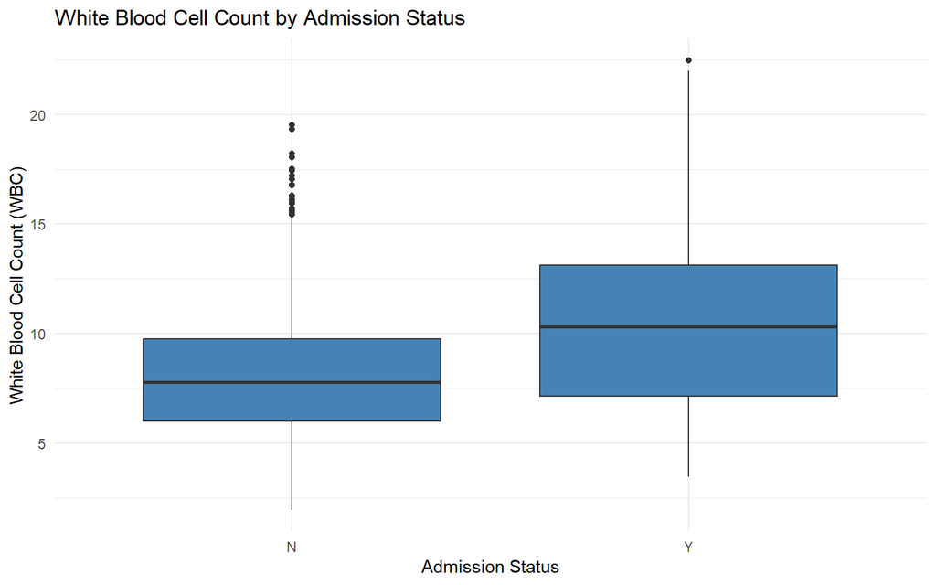

```r
# Remove observations with missing admission status
wbc_plot <- subset(
  df_analysis,
  !is.na(`Admitted (Y/N)`)
)

# creating the box plot
ggplot(
  wbc_plot,
  aes(
    x = `Admitted (Y/N)`,
    y = WBC
  )
) +
  geom_boxplot(fill = "steelblue") +
  labs(
    title = "White Blood Cell Count by Admission Status",
    x = "Admission Status",
    y = "White Blood Cell Count (WBC)"
  ) +
  theme_minimal()
```

## Figure 2: Forest Graph

Figure 2 displays the adjusted odds ratios and 95% confidence intervals from the multivariable logistic regression model.

Figure 2 displays the adjusted odds ratios and 95% confidence intervals from the multivariable logistic regression model. Variables whose 95% confidence intervals did not include an odds ratio of 1 showed statistically significant associations with hospital admission after adjustment. Vomiting, epigastric tenderness, lumbar tenderness, RIF tenderness, higher WBC counts, obstructive LFT findings, and higher lipase levels were associated with increased odds of hospital admission.

```
## `height` was translated to `width`.
```

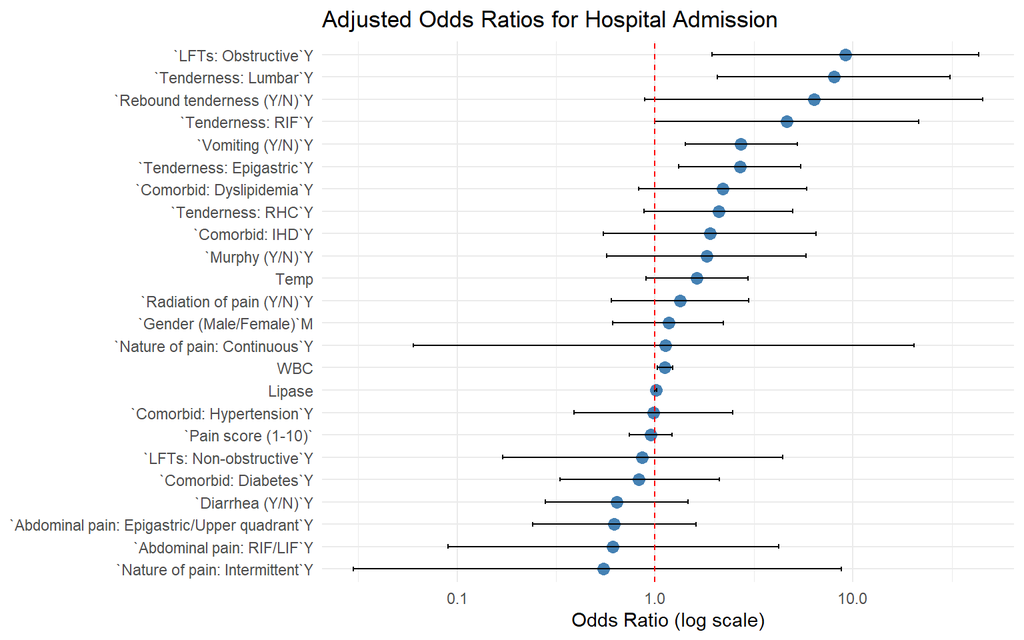

```r
# copying the coefficient table
forest_df <- coef_table

# Removing the intercept from the logistic regression model
forest_df <- subset(forest_df,
                    Variable != "(Intercept)")

#generating the forest graph
ggplot(
  forest_df,
  aes(
    x = Odds_Ratio,
    y = reorder(Variable, Odds_Ratio)
  )
) +
  geom_point(size = 3, colour = "steelblue") +
  geom_errorbarh(
    aes(
      xmin = CI_Lower,
      xmax = CI_Upper
    ),
    height = 0.2
  ) +
  geom_vline(
    xintercept = 1,
    linetype = "dashed",
    colour = "red"
  ) +
  scale_x_log10() +
  labs(
    title = "Adjusted Odds Ratios for Hospital Admission",
    x = "Odds Ratio (log scale)",
    y = NULL
  ) +
  theme_minimal()
```

## Figure 3: ROC curve to evaluate the multivariable logistic regression model performance

The ROC curve was used to evaluate the discriminatory performance of the multivariable logistic regression model. Unlike the forest plot, which presents the adjusted association between each individual predictor and hospital admission, the ROC curve evaluates the performance of the overall multivariable model in distinguishing between patients who were admitted and those who were not admitted. The model included the 24 variables that demonstrated statistically significant associations with hospital admission in the univariable analyses.

The area under the ROC curve (AUC) was 0.879, indicating that the model demonstrated good discriminatory ability in distinguishing between admitted and non-admitted patients based on the combined predictors included in the model.

This suggests that the combined information from the predictors included in the model provides useful discrimination between the two admission groups, although not all 24 predictors remained statistically significant after adjustment.

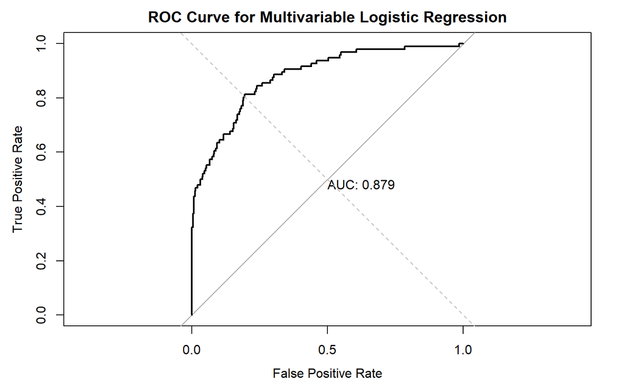

```r
# Get the observations actually used in the logistic regression model
model_data <- model.frame(multivariable_model)

# Actual admission status for those observations
actual_outcome <- model.response(model_data)

# Predicted probability of hospital admission
predicted_probability <- predict(
  multivariable_model,
  type = "response"
)

# Create ROC curve
roc_curve <- roc(
  response = actual_outcome,
  predictor = predicted_probability,
  levels = c("N", "Y"),
  direction = "<"
)

# Plot ROC curve
plot(
  roc_curve,
  legacy.axes = TRUE,
  print.auc = TRUE,
  main = "ROC Curve for Multivariable Logistic Regression",
  xlab = "False Positive Rate",
  ylab = "True Positive Rate"
)

# Add reference line
abline(
  a = 0,
  b = 1,
  lty = 2,
  col = "grey"
)
```

```r
# Calculate AUC
auc(roc_curve)
```

```
## Area under the curve: 0.8789
```

## Figure 4: Heat map showing hospital admission rates by vomiting status and lipase level

Each cell represents the percentage of patients within the corresponding Lipase and vomiting group who were admitted to hospital. Patients who vomited and had high levels of lipase had the highest levels of hospital admission which was 45.7%.

This pattern is consistent with the multivariable logistic regression, in which both vomiting and lipase showed statistically significant associations with hospital admission after adjustment for the other variables in the model.

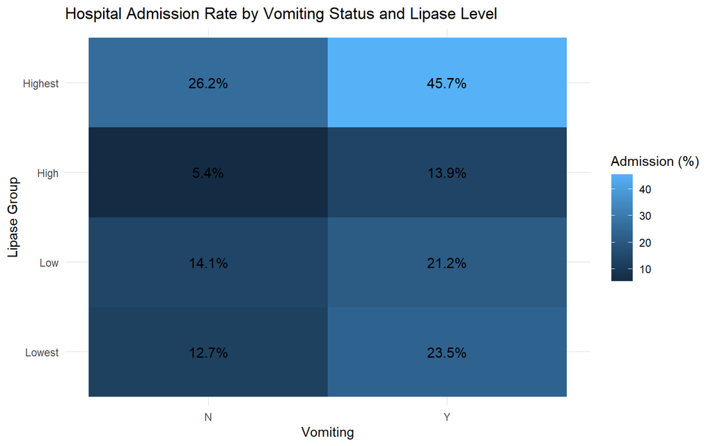

```r
# Create a copy containing the variables needed for the heat map
heatmap_df <- df_analysis %>%
  select(
    `Vomiting (Y/N)`,
    Lipase,
    `Admitted (Y/N)`
  ) %>%
  filter(
    !is.na(`Vomiting (Y/N)`),
    !is.na(Lipase),
    !is.na(`Admitted (Y/N)`)
  )

# Create four Lipase groups based on quartiles
heatmap_df <- heatmap_df %>%
  mutate(
    Lipase_Group = cut(
      Lipase,
      breaks = quantile(
        Lipase,
        probs = c(0, 0.25, 0.50, 0.75, 1),
        na.rm = TRUE
      ),
      include.lowest = TRUE,
      labels = c(
        "Lowest",
        "Low",
        "High",
        "Highest"
      )
    )
  )

# Calculate percentage admitted within each combination
heatmap_summary <- heatmap_df %>%
  group_by(`Vomiting (Y/N)`, Lipase_Group) %>%
  summarise(
    Admission_Rate = mean(`Admitted (Y/N)` == "Y") * 100,
    .groups = "drop"
  )

# Create heat map
ggplot(
  heatmap_summary,
  aes(
    x = `Vomiting (Y/N)`,
    y = Lipase_Group,
    fill = Admission_Rate
  )
) +
  geom_tile() +
  geom_text(
    aes(
      label = paste0(
        round(Admission_Rate, 1),
        "%"
      )
    ),
    size = 4
  ) +
  scale_fill_gradient(
    name = "Admission (%)"
  ) +
  labs(
    title = "Hospital Admission Rate by Vomiting Status and Lipase Level",
    x = "Vomiting",
    y = "Lipase Group"
  ) +
  theme_minimal()
```

# Discussion

## What did the study find?

The study identified six variables that remained statistically significantly associated with hospital admission after adjustment for the other variables in the multivariable logistic regression model: vomiting, epigastric tenderness, lumbar tenderness, WBC, obstructive LFTs, and lipase. RIF tenderness showed borderline evidence of an association with hospital admission (p = 0.0500).

The study also found that the multivariable logistic regression model, which included the 24 variables that showed statistically significant associations in the univariable analysis, demonstrated good ability to discriminate between patients who were and were not admitted to hospital, with an AUC of 0.879.

## Comparison with previous studies

Literature on each statistically significant variable from the multi-variable logistic regression was examined and the findings were:

**Vomitting**

Previous clinical guidelines report that patients with acute abdomen commonly present with nausea and vomiting, among other symptoms (Mayumi et al., 2015). This provides a possible clinical explanation for the association between vomiting and hospital admission observed in the present study, although the guidelines do not establish that vomiting independently predicts hospital admission.

**Epigastric Tenderness**

Previous research has identified epigastric tenderness as a physical examination finding among patients presenting with abdominal pain (Pines et al., 2005). This provides clinical context for the finding observed in the present study, although the previous study did not specifically examine whether epigastric tenderness was associated with hospital admission.

**Lumbar Tenderness**

The mechanism underlying the association between lumbar tenderness and hospital admission is unclear. The original dataset did not provide sufficient information to determine whether lumbar tenderness represented musculoskeletal, renal, or another underlying source of pain. Therefore, this finding should be interpreted cautiously and requires further investigation.

**WBC**

WBC was significantly associated with hospital admission in this study. This finding may reflect the role of WBC as a marker of inflammation, as WBC counts are routinely assessed during the clinical workup of patients presenting with acute abdominal pain.

However, previous research has found that WBC alone is a weak discriminator between urgent and nonurgent causes of acute abdominal pain, suggesting that WBC should not be interpreted as an independent indicator of disease severity (Metodologica et al., 2015).

**Obstructive LFTs**

Obstructive LFT findings were associated with increased odds of hospital admission (OR 9.14, 95% CI 1.94–43.16). However, the literature search did not identify strong evidence directly examining the relationship between obstructive LFT findings and hospital admission among patients presenting with acute abdominal pain. Therefore, the observed association in this study should be interpreted cautiously. The wide confidence interval also indicates considerable uncertainty regarding the magnitude of the association.

**Lipase**

Lipase was also significantly associated with hospital admission, with each one-unit increase in lipase associated with a 1% increase in the odds of admission (OR 1.01, 95% CI 1.00–1.02).

This finding may reflect the presence of underlying abdominal pathology, as previous research has reported that elevated serum lipase, alongside abdominal pain, is commonly used in the diagnosis of acute pancreatitis, with lipase considered a useful diagnostic biomarker for the condition (Ismail & Bhayana, 2017).

This may partly explain the observed association between lipase levels and hospital admission, although the present study cannot determine whether acute pancreatitis or another underlying condition accounted for the elevated lipase levels.

## Possible explainations for findings

The associations observed in this study may reflect the underlying clinical characteristics of patients who required hospital admission. Vomiting and epigastric tenderness may indicate the presence of underlying abdominal pathology, while elevated WBC and lipase levels may reflect inflammatory or other pathological processes requiring further investigation and management. Similarly, obstructive LFT findings may indicate underlying hepatobiliary pathology, which could contribute to the decision to admit a patient. However, the available data do not allow the specific underlying causes of these findings to be determined.

The association between lumbar tenderness and hospital admission is more difficult to explain. Lumbar tenderness may arise from several different underlying conditions, including renal, musculoskeletal, or abdominal causes. Because the dataset did not provide sufficient information to distinguish between these causes, it is not possible to determine why lumbar tenderness was associated with admission in this study. Similarly, although epigastric tenderness was associated with admission, the available literature identified in this study primarily describes epigastric tenderness as a finding among patients presenting with abdominal pain rather than directly examining its relationship with hospital admission. Therefore, these associations should be interpreted cautiously and may warrant further investigation.

## Study Strengths

One strength of this study is the relatively large sample size (n = 957), which provided a substantial number of observations for statistical analysis. A further strength was the assessment of data completeness before analysis, with variables containing more than 60% missing values excluded. This reduced the potential impact of variables with substantial missing data on the analysis.

Another strength was the availability of a broad range of demographic, clinical, physical examination, and laboratory variables in the dataset. This allowed multiple potential factors associated with hospital admission to be examined and enabled adjustment for several variables in the multivariable logistic regression model.

The use of both univariable and multivariable analyses was also a strength. Univariable analyses were initially used to identify variables potentially associated with hospital admission, while multivariable logistic regression allowed the associations of the selected variables to be examined simultaneously. The performance of the final model was also assessed using an ROC curve, which provided an overall measure of the model’s ability to discriminate between admitted and non-admitted patients.

## Study Limitations

This study has several limitations. First, the dataset did not provide sufficient clinical detail to determine the specific location or underlying cause of lumbar tenderness. Lumbar tenderness may have different clinical meanings depending on its precise anatomical location and underlying cause, such as renal, musculoskeletal, or abdominal pathology. Therefore, it is difficult to determine why lumbar tenderness was associated with hospital admission in this study, and the finding should be interpreted cautiously.

Second, variables were selected for the multivariable logistic regression based on their statistical significance in the univariable analysis. This approach may exclude variables that are clinically important but did not demonstrate statistical significance in the univariable analysis. Conversely, some variables may have appeared significant in the univariable analysis because of their relationship with other predictors. Therefore, the variables included in the final model may not represent all clinically relevant factors associated with hospital admission.

Third, the observational nature of the dataset means that the study can identify associations but cannot establish causality. Although six variables remained statistically significantly associated with hospital admission after adjustment, it cannot be concluded that these variables directly caused hospital admission.

Fourth, although variables with more than 60% missing values were excluded from the analysis, missing data remained within the variables that were analysed. This may have reduced the available sample size for some analyses and could potentially introduce bias if the missing observations were not missing at random.

Finally, the ROC curve assessed model discrimination using the same dataset from which the model was developed. Therefore, the AUC of 0.879 may overestimate the model’s performance in an independent patient population. External validation using a separate dataset would be required to determine how well the model generalises to other patients.

## Suggestions for future research

Future research could address several of the limitations identified in this study. First, future studies could use larger datasets with more complete data to reduce the potential impact of missing values and improve the precision of the estimated associations.

Second, future studies could use a separate dataset to externally validate the multivariable logistic regression model. This would determine whether the model’s ability to discriminate between patients who are and are not admitted to hospital, observed in this study (AUC = 0.879), is maintained in an independent patient population.

Third, future datasets should provide more detailed information about physical examination findings, particularly lumbar tenderness. Specifying the precise anatomical location and potential underlying cause of tenderness could help determine why lumbar tenderness was associated with hospital admission in this study.

Finally, future research could investigate whether the associations identified in this study remain consistent in larger and more diverse patient populations. Replication of the findings would provide greater confidence that the observed associations are not specific to the current study population.

# Conclusion

This study identified six variables that remained statistically significantly associated with hospital admission among patients presenting with abdominal pain: vomiting, epigastric tenderness, lumbar tenderness, WBC, obstructive LFT findings, and lipase. RIF tenderness showed borderline evidence of an association. The multivariable logistic regression model demonstrated good discrimination between patients who were and were not admitted to hospital, with an AUC of 0.879.

These findings suggest that a combination of clinical presentation, physical examination findings, and laboratory measurements may help distinguish patients requiring hospital admission from those who do not. However, the findings represent associations rather than causal relationships, and some estimates, particularly for lumbar tenderness and obstructive LFT findings, were imprecise because of wide confidence intervals. Further research using larger and more complete datasets, more detailed clinical information, and independent external validation would be needed to determine whether these findings can be generalised to other patient populations.

# References

Cleveland Clinic (2025) Abdominal Pain, Cleveland Clinic. Available at: https://my.clevelandclinic.org/health/symptoms/4167-abdominal-pain (Accessed: 06 August 2026).

Dadeh, A. and Phunyanantakorn, P. (2020) ‘Factors affecting length of stay in the emergency department in patients who presented with abdominal pain’, Emergency Medicine International, 2020, pp. 1–7. doi:10.1155/2020/5406516.

Ismail, O.Z. and Bhayana, V. (2017) ‘Lipase or amylase for the diagnosis of acute pancreatitis?’, Clinical Biochemistry, 50(18), pp. 1275–1280. doi:10.1016/j.clinbiochem.2017.07.003.

Mayumi, T. et al. (2015) ‘Practice guidelines for primary care of acute abdomen 2015’, Journal of Hepato-Biliary-Pancreatic Sciences, 23(1), pp. 3–36. doi:10.1002/jhbp.303.

Metodologica , G. di A., Paolillo, C. and Spallino, I. (2015) ‘Can C-reactive protein and white blood cell count alone rule out an urgent condition in acute abdominal pain?’, Internal and Emergency Medicine, 11(1), pp. 141–142. doi:10.1007/s11739-015-1333-2.

Pines, J. et al. (2005) ‘The interrater variation of Ed abdominal examination findings in patients with acute abdominal pain’, The American Journal of Emergency Medicine, 23(4), pp. 483–487. doi:10.1016/j.ajem.2004.09.034.

Wolfe, C. et al. (2022) ‘Abdominal pain in the emergency department: How to select the correct imaging for diagnosis’, Open Access Emergency Medicine, Volume 14, pp. 335–345. doi:10.2147/oaem.s342724.

# Appendix A: Full Column Description

| Variable | Description | Type |
| --- | --- | --- |
| `Age (years)` (14-96) | Patient’s Age | Numerical Discrete |
| `Gender (Male/Female)` (primarily coded as M/F; rare anomalous entries observed) | Patient’s Gender | Categorical Nominal |
| `Comorbid: Diabetes` (Y/N) | Whether the patient has diabetes as a comorbidity | Categorical Nominal |
| `Comorbid: Hypertension` (Y/N) | Whether the patient has hypertension as a comorbidity | Categorical Nominal |
| `Comorbid: CKD` (primarily coded as Y/N; rare anomalous entries observed) | Whether the patient has Chronic Kidney Disease (CKD) as a comorbidity | Categorical Nominal |
| `Comorbid: IHD` (Y/N) | Whether the patient has Ischemic Heart Disease (IHD) as a comorbidity | Categorical Nominal |
| `Comorbid: Bronchial Asthma` (primarily coded as Y/N; rare anomalous entries observed) | Whether the patient has Bronchial Asthma as a comorbidity | Categorical Nominal |
| `Comorbid: Dyslipidemia` (primarily coded as Y/N; rare anomalous entries observed) | Whether the patient has Dyslipidemia as a comorbidity | Categorical Nominal |
| `Comorbid: Others` | Free-text field recording additional comorbidities not captured by the predefined comorbidity variables | Text / Unstructured Data |
| `Ethnicity: Arabs` (primarily coded as Y/N; rare anomalous entries observed) | Whether the patient is Arab | Categorical Nominal |
| `Ethnicity: Muslims (non-Arabs)` (Y/N) | Whether the patient is a non-Arab Muslim | Categorical Nominal |
| `Ethnicity: Others` (Y/N) | Whether the patient belongs to an ethnicity category other than Arab or Muslim (non-Arab) | Categorical Nominal |
| `Nationality: Bahraini` (Y/N) | Whether the patient is a Bahraini national | Categorical Nominal |
| `Nationality: Other Arabs` (Y/N) | Whether the patient is a national of another Arab country | Categorical Nominal |
| `Nationality: Expats` (primarily coded as Y/N; rare anomalous entries observed) | Whether the patient is a Expat (non-Arab foreign national residing in the UAE) | Categorical Nominal |
| `Abdominal pain: Localized` (Y/N) | Whether the patient had localized abdominal pain | Categorical Nominal |
| `Abdominal pain: Epigastric/Upper quadrant` (Y/N) | Whether the patient had epigastric/upper quadrant abdominal pain | Categorical Nominal |
| `Abdominal pain: RIF/LIF` (Values were primarily recorded as Y/N but contained additional location-specific entries (e.g., “Y, RIF”, “LIF”)) | Whether the patient experienced pain in the right iliac fossa (RIF) or left iliac fossa (LIF) | Categorical Nominal |
| `Abdominal pain: Lumbar` (Y/N) | Whether the patient experienced lumbar abdominal pain | Categorical Nominal |
| `Abdominal pain: Suprapubic` (primarily coded as Y/N; rare anomalous entries observed) | Whether the patient experienced suprapubic abdominal pain | Categorical Nominal |
| `Abdominal pain: Generalized` (primarily coded as Y/N; rare anomalous entries observed) | Whether the patient had generalized abdominal pain | Categorical Nominal |
| `Duration of pain: Acute <24h` (primarily coded as Y/N; rare anomalous entries observed) | Whether the patients abdominal pain was present for less than 24 hours | Categorical Nominal |
| `Duration of pain: >24h` (Y/N) | Whether the patients abdominal pain was present for more than 24 hours | Categorical Nominal |
| `Fever (Y/N)` (Y/N) | Whether the patient had a fever | Categorical Nominal |
| `Vomiting (Y/N)` (Y/N) | Whether the patient vomited | Categorical Nominal |
| `Diarrhea (Y/N)` (Y/N) | Whether the patient had diarrhea | Categorical Nominal |
| `Constipation (Y/N)` (primarily coded as Y/N; rare anomalous entries observed) | Whether the patient had constipation | Categorical Nominal |
| `Radiation of pain (Y/N)` (Y/N) | Whether the patient’s abdominal pain radiated or spread from its primary location to another area of the body. | Categorical Nominal |
| `Pain score (1-10)` (1-10) | The severity of abdominal pain that a patient felt from a scale of 1-10 | Numerical Discrete |
| `Dysuria (Y/N)` (Y/N) | Whether the patient had pain, discomfort, or a burning sensation during urination | Categorical Nominal |

[output cut: 52 more lines]